# Project 3 Sea Surface Temperature Measurements

Due at 11:59 pm on Thursday, October 25  
Name: Yaohua Chang  
Name: Jiffar Abakoyas

```r
#Initial Libraries
library(ncdf4)
library(leaps)
library(pracma)
library(glmnet)
```

## Background

Polar-orbiting satellites have been carrying variety of radiometer instruments with infrared (IR) channels suitable for estimating sea surface temperature (SST) since 1981. The instruments designed for SST estimations have channels that are located at selected wavelengths where the atmosphere is relatively transparent. At these IR wavelengths the ocean surface emits radiation almost as a blackbody. In principle, without an absorbing and emitting atmosphere between the sea surface and the satellite, it would be possible to estimate SST using a single-channel measurement. In reality, surface-leaving IR radiance is partially attenuated by the atmosphere before it reaches a satellite sensor. Therefore it is necessary to make corrections for atmospheric effects [Minnett, 1990]. Several techniques have been proposed over the years to account for the atmospheric absorption of surface IR radiance to improve the accuracy of satellite retrievals of SST. Anding and Kauth [1970] found that the difference in measurement at two properly selected IR channels is proportional to the amount of atmospheric correction required. Using differences in brightness temperatures (BT) measured by an early satellite radiometer, [Prabhakra et. al. 1974] estimated SST to reasonable accuracy. Barton [1995] showed that this differential absorption between channels is exploited in all IR SST algorithms and demonstrated that there is a basic form to most algorithms.

## Load Data

```r
In <- nc_open("/Users/changyaohua/Desktop/project\ 3/matchups_NPP_2018-01.nc")
In2 <- nc_open("/Users/changyaohua/Desktop/project\ 3/matchups_NPP_2018-02.nc")

#to see all the variable names in ncdf file:
names(In$var)
```

```
##  [1] "plat_type"  "quality"    "time_diff"  "distance"   "year"
##  [6] "month"      "day"        "hour"       "minute"     "acspo_mask"
## [11] "air_temp"   "BT_M12"     "BT_M13"     "BT_M14"     "BT_M15"
## [16] "BT_M16"     "latitude"   "longitude"  "sst_ref"    "sst_reg"
## [21] "raz"        "sza"        "tpw"        "wind"       "vza"
## [26] "sst_insitu"
```

```r
sst_reg <- ncvar_get(In, "sst_reg")
sst_insitu <- ncvar_get(In, "sst_insitu")
sst_ref <- ncvar_get(In, "sst_ref")
sza <- ncvar_get(In, 'sza')
vza <- ncvar_get(In, 'vza')

sec_theta = sec(vza) - 1

BT_M12 <- ncvar_get(In, "BT_M12")
BT_M13 <- ncvar_get(In, "BT_M13")
BT_M14 <- ncvar_get(In, "BT_M14")
BT_M15 <- ncvar_get(In, "BT_M15")
BT_M16 <- ncvar_get(In, "BT_M16")


dataframe1 = data.frame(sst_insitu, BT_M12, BT_M13, BT_M14, BT_M15, BT_M16)
head(dataframe1)
```

```
##   sst_insitu   BT_M12   BT_M13   BT_M14   BT_M15   BT_M16
## 1     290.53 289.9229 285.7964 285.9967 288.6486 287.8731
## 2     290.53 289.8424 285.7609 285.8882 288.5992 287.8263
## 3     290.53 289.9028 285.7587 285.9219 288.5992 287.7794
## 4     290.53 289.8323 285.7563 285.9593 288.5621 287.7752
## 5     290.53 289.7542 285.6973 285.8509 288.4302 287.6900
## 6     290.53 289.8424 285.7943 286.1089 288.6609 287.9157
```

## Question 1

Use subset selection methods to find the best 2 variables𝜆! in equation (1).  
Since there are only 2 variables, exhaustive search is an appropriate method.

```r
# Question 1
# Use subset selection methods to find the best two-variable model using exhaustive search.
regfit.full = regsubsets(sst_insitu ~ ., data = dataframe1, nvmax=2)
reg.summary = summary(regfit.full)

reg.summary$rsq
```

```
## [1] 0.9246508 0.9793620
```

```r
reg.summary$which
```

```
##   (Intercept) BT_M12 BT_M13 BT_M14 BT_M15 BT_M16
## 1        TRUE  FALSE  FALSE  FALSE   TRUE  FALSE
## 2        TRUE  FALSE  FALSE  FALSE   TRUE   TRUE
```

**Conclusion:** The output indicates that the best two-variable model contains only BT_M15 and BT_M16.

```r
model1 = lm(sst_insitu ~ BT_M15 + I(BT_M16 - BT_M15), data = dataframe1)

model2 = lm(sst_insitu ~ BT_M16 + I(BT_M15 - BT_M16), data = dataframe1)

# To evaluate the performance of model1, the adjusted R squared is 0.979362
summary1 = summary(model1)
model1_adj_r_squared = summary1$adj.r.squared
summary1$coefficients
```

```
##                      Estimate   Std. Error    t value Pr(>|t|)
## (Intercept)         1.9625623 1.665454e-02   117.8395        0
## BT_M15              0.9962717 5.869381e-05 16974.0504        0
## I(BT_M16 - BT_M15) -3.2038856 6.224828e-04 -5146.9467        0
```

```r
# the performance of equation(1)
model1_adj_r_squared
```

```
## [1] 0.979362
```

```r
sqrt(mean(model1$residuals ^ 2))
```

```
## [1] 1.046112
```

```r
# To evaluate the performance of model2, the adjusted R squared is 0.979362 as well
summary2 = summary(model2)
model2_adj_r_squared = summary2$adj.r.squared
summary2$coefficients
```

```
##                     Estimate   Std. Error    t value Pr(>|t|)
## (Intercept)        1.9625623 1.665454e-02   117.8395        0
## BT_M16             0.9962717 5.869381e-05 16974.0504        0
## I(BT_M15 - BT_M16) 4.2001572 5.999287e-04  7001.0944        0
```

```r
# the performance of equation(1)
model2_adj_r_squared
```

```
## [1] 0.979362
```

```r
sqrt(mean(model2$residuals ^ 2))
```

```
## [1] 1.046112
```

# Question 2

Use a selection method to find the best coefficients in the equation (2).  
Compare the performance with (1) and with operational Ts (‘sst_reg’ of netcdf).  
Use independent data set for evaluation.

```r
model3 = lm(sst_insitu ~ BT_M15 + I(BT_M15 - BT_M16):sst_ref + I(BT_M15 - BT_M16):sec_theta, data = dataframe1)
summary3 = summary(model3)
model3_adj_r_squared = summary3$adj.r.squared
summary3$coefficients
```

```
##                                  Estimate   Std. Error      t value
## (Intercept)                  4.456660e+00 1.670006e-02   266.864926
## BT_M15                       9.878219e-01 5.888247e-05 16776.161705
## I(BT_M15 - BT_M16):sst_ref   1.068495e-02 2.052484e-06  5205.861983
## I(BT_M15 - BT_M16):sec_theta 7.287717e-07 2.091278e-07     3.484815
##                                  Pr(>|t|)
## (Intercept)                  0.0000000000
## BT_M15                       0.0000000000
## I(BT_M15 - BT_M16):sst_ref   0.0000000000
## I(BT_M15 - BT_M16):sec_theta 0.0004924802
```

```r
# the performance of equation(2)
model3_adj_r_squared
```

```
## [1] 0.9797013
```

```r
sqrt(mean(model3$residuals ^ 2))
```

```
## [1] 1.037475
```

```r
# the performance of operational 𝑇
sqrt(mean((sst_insitu - sst_reg) ^ 2))
```

```
## [1] 0.3289296
```

| Model | RMSE | R<sup>2</sup> |
| --- | --- | --- |
| equation (2) | 1.037475 | 0.9797013 |
| equation (1) | 1.046112 | 0.979362 |
| operational Ts | 0.3289296 | null |

**Conclusion:** the performance of equation (2) is better than equation (1) a little bit, but it is worse than operational Ts.

## Question 3

```r
model4 = lm(sst_insitu ~ BT_M15 + I(BT_M15 - BT_M16):sst_ref + I(BT_M15 - BT_M16):sec_theta + sst_ref, data = dataframe1)
summary4 = summary(model4)
model4_adj_r_squared = summary4$adj.r.squared
summary4$coefficients
```

```
##                                   Estimate   Std. Error       t value
## (Intercept)                  -1.047693e+00 3.853098e-03  -271.9091887
## BT_M15                        2.911326e-02 7.274698e-05   400.1989495
## sst_ref                       9.749150e-01 7.269016e-05 13411.9250097
## I(BT_M15 - BT_M16):sst_ref    2.562337e-04 9.090256e-07   281.8773157
## I(BT_M15 - BT_M16):sec_theta -1.744286e-08 4.797628e-08    -0.3635726
##                               Pr(>|t|)
## (Intercept)                  0.0000000
## BT_M15                       0.0000000
## sst_ref                      0.0000000
## I(BT_M15 - BT_M16):sst_ref   0.0000000
## I(BT_M15 - BT_M16):sec_theta 0.7161772
```

```r
# the performance of equation(3)
model4_adj_r_squared
```

```
## [1] 0.9989317
```

```r
sqrt(mean(model4$residuals ^ 2))
```

```
## [1] 0.2380083
```

| Model | RMSE | R<sup>2</sup> |
| --- | --- | --- |
| equation (2a) | 0.2380083 | 0.9989317 |
| equation (2) | 1.037475 | 0.9797013 |
| equation (1) | 1.046112 | 0.979362 |
| operational Ts | 0.3289296 | null |

# Question 4

Estimate the coefficients using shrinkage methods (Lasso and Ridge regression).  
Evaluate and compare with operational Ts.  
Use independent data set for evaluation.

### Regression Equation night (3n)

```r
#Lasso and Ridge methods involve regularization of regression coefficients.

#In Ridge Regression, the ordinary least squares loss function is augmented in such a way that the sum of squared residuals is minimized #but also the size of parameter estimates are penalized in order to shrink them towards zero:

#In Lasso (Least Absolute Shrinkage and Selection Operator), similar to Ridge, also adds a penalty for non-zero coefficients, but unlike #ridge regression which penalizes sum of squared coefficients, Lasso penalizes the sum of absolute values.

#As a result, for high values of λ, many coefficients are exactly zeroed under lasso, which is never the case in ridge regression.



dataframe2 = data.frame(sza,sec_theta,sst_insitu, BT_M12, BT_M13, BT_M14, BT_M15, BT_M16, sst_ref)
head(dataframe2,10)
```

```
##         sza sec_theta sst_insitu   BT_M12   BT_M13   BT_M14   BT_M15
## 1  57.05766 -2.819339     290.53 289.9229 285.7964 285.9967 288.6486
## 2  57.05279 -3.017484     290.53 289.8424 285.7609 285.8882 288.5992
## 3  57.04793 -3.274302     290.53 289.9028 285.7587 285.9219 288.5992
## 4  57.04308 -3.617953     290.53 289.8323 285.7563 285.9593 288.5621
## 5  57.03823 -4.098470     290.53 289.7542 285.6973 285.8509 288.4302
## 6  57.06895 -2.662530     290.53 289.8424 285.7943 286.1089 288.6609
## 7  57.06408 -2.819138     290.53 289.9129 285.8249 285.9556 288.6156
## 8  57.05922 -3.017228     290.53 289.7719 285.7115 285.8770 288.5250
## 9  57.05437 -3.273966     290.53 289.8449 285.7131 285.8770 288.5291
## 10 57.04952 -3.617494     290.53 289.8474 285.7152 285.9144 288.5332
##      BT_M16  sst_ref
## 1  287.8731 290.9484
## 2  287.8263 290.9282
## 3  287.7794 290.9093
## 4  287.7752 290.8926
## 5  287.6900 290.8759
## 6  287.9157 290.9591
## 7  287.8263 290.9390
## 8  287.7369 290.9189
## 9  287.7411 290.9004
## 10 287.6943 290.8837
```

```r
night_time = dataframe2[(dataframe2$sza >= 95) & (dataframe2$sza <= 180), ]
head(night_time)
```

```
##           sza sec_theta sst_insitu   BT_M12   BT_M13   BT_M14   BT_M15
## 2528 136.1304  2.059741     278.95 276.7133 269.9073 272.6413 275.6404
## 2529 136.1277  1.853162     278.95 276.4640 269.7423 272.4655 275.5950
## 2530 136.1249  1.674373     278.95 276.5899 269.7374 272.6002 275.6445
## 2531 136.1222  1.518257     278.95 276.4665 269.8900 272.6375 275.7434
## 2532 136.1195  1.380860     278.95 276.8291 270.0391 272.8469 275.9412
## 2533 136.1167  1.259031     278.95 276.8216 269.8682 272.7946 275.8835
##        BT_M16  sst_ref
## 2528 274.6314 279.0973
## 2529 274.6782 279.0782
## 2530 274.6740 279.0614
## 2531 274.7208 279.0562
## 2532 274.9167 279.0511
## 2533 274.8187 279.0459
```

```r
x_night=model.matrix(sst_insitu ~  BT_M15 + I(BT_M15 - BT_M12) + I(BT_M15 - BT_M14) + I(BT_M15 - BT_M16)
               + sec_theta + BT_M15:sec_theta + I(BT_M15 - BT_M12):sec_theta
               + I(BT_M15 - BT_M14):sec_theta
               + I(BT_M15 - BT_M16):sec_theta + BT_M15:sst_ref + I(BT_M15 - BT_M12):sst_ref
               + I(BT_M15 - BT_M14):sst_ref + I(BT_M15 - BT_M16):sst_ref, night_time)[,-1]
y_night=as.vector(night_time$sst_insitu)

set.seed (1)
train=sample(1:nrow(x_night), nrow(x_night)/2)
test=(-train)
y_night.test=y_night[test]

#set.seed (1)
#cv.out=cv.glmnet(x[train ,],y[train],alpha=0, nfolds=3)
#bestlam=cv.out$lambda.min
#bestlam

grid=10^seq(10,-2,length=100)

#Ridge regression for night (3n)
out=glmnet(x_night,y_night,alpha=0)
ridge.mod=glmnet(x_night,y_night,alpha=0,lambda=grid)
ridge.pred=predict(ridge.mod,s=min(out$lambda) ,newx=x_night[test,])
# Estimate the coefficients using ridge regression
predict(out,type="coefficients",s=min(out$lambda))[1:14,]
```

```
##                  (Intercept)                       BT_M15
##                 8.307455e+01                 4.855454e-01
##           I(BT_M15 - BT_M12)           I(BT_M15 - BT_M14)
##                -6.050019e-01                 9.239010e-02
##           I(BT_M15 - BT_M16)                    sec_theta
##                 1.675837e-01                -1.148235e-07
##             BT_M15:sec_theta I(BT_M15 - BT_M12):sec_theta
##                -4.222206e-10                -1.478956e-07
## I(BT_M15 - BT_M14):sec_theta I(BT_M15 - BT_M16):sec_theta
##                 8.683036e-08                 7.974247e-08
##               BT_M15:sst_ref   I(BT_M15 - BT_M12):sst_ref
##                 7.701353e-04                -2.095204e-03
##   I(BT_M15 - BT_M14):sst_ref   I(BT_M15 - BT_M16):sst_ref
##                 2.551569e-03                 1.021424e-03
```

```r
# The performance of equation(3n) using ridge regression
sqrt(mean((ridge.pred-y_night.test)^2))
```

```
## [1] 0.4893441
```

```r
# Lasso regression for night (3n)
out=glmnet(x_night,y_night,alpha=1)
lasso.mod=glmnet(x_night[train ,],y_night[train],alpha=1,lambda=grid)
lasso.pred=predict(lasso.mod,s=min(out$lambda) ,newx=x_night[test,])
# Estimate the coefficients using Lasso regression
predict(out,type="coefficients",s=min(out$lambda))[1:14,]
```

```
##                  (Intercept)                       BT_M15
##                144.934311455                  0.000000000
##           I(BT_M15 - BT_M12)           I(BT_M15 - BT_M14)
##                  0.000000000                  0.000000000
##           I(BT_M15 - BT_M16)                    sec_theta
##                  0.000000000                  0.000000000
##             BT_M15:sec_theta I(BT_M15 - BT_M12):sec_theta
##                  0.000000000                  0.000000000
## I(BT_M15 - BT_M14):sec_theta I(BT_M15 - BT_M16):sec_theta
##                  0.000000000                  0.000000000
##               BT_M15:sst_ref   I(BT_M15 - BT_M12):sst_ref
##                  0.001716722                 -0.002912646
##   I(BT_M15 - BT_M14):sst_ref   I(BT_M15 - BT_M16):sst_ref
##                  0.001953446                  0.000000000
```

```r
# The performance of equation(3n) using Lasso regression
sqrt(mean((lasso.pred-y_night.test)^2))
```

```
## [1] 0.2767067
```

### Regression Equation day (3d)

```r
day_time = dataframe2[(dataframe2$sza >= 0) & (dataframe2$sza <= 85), ]
head(day_time)
```

```
##        sza sec_theta sst_insitu   BT_M12   BT_M13   BT_M14   BT_M15
## 1 57.05766 -2.819339     290.53 289.9229 285.7964 285.9967 288.6486
## 2 57.05279 -3.017484     290.53 289.8424 285.7609 285.8882 288.5992
## 3 57.04793 -3.274302     290.53 289.9028 285.7587 285.9219 288.5992
## 4 57.04308 -3.617953     290.53 289.8323 285.7563 285.9593 288.5621
## 5 57.03823 -4.098470     290.53 289.7542 285.6973 285.8509 288.4302
## 6 57.06895 -2.662530     290.53 289.8424 285.7943 286.1089 288.6609
##     BT_M16  sst_ref
## 1 287.8731 290.9484
## 2 287.8263 290.9282
## 3 287.7794 290.9093
## 4 287.7752 290.8926
## 5 287.6900 290.8759
## 6 287.9157 290.9591
```

```r
x_day=model.matrix(sst_insitu ~ BT_M15 + I(BT_M15 - BT_M14) + I(BT_M15 - BT_M16) + sec_theta
                   + BT_M15:sec_theta
                   + I(BT_M15 - BT_M14):sec_theta + I(BT_M15 - BT_M16):sec_theta + BT_M15:sst_ref
                   + I(BT_M15 - BT_M14):sst_ref + I(BT_M15 - BT_M16):sst_ref, day_time)[,-1]
y_day=as.vector(day_time$sst_insitu)

set.seed (1)
train=sample(1:nrow(x_day), nrow(x_day)/2)
test=(-train)
y_day.test=y_day[test]

grid=10^seq(10,-2,length=100)

# Ridge regression for day (3d)
out=glmnet(x_day,y_day,alpha=0)
ridge.mod=glmnet(x_day,y_day,alpha=0,lambda=grid)
ridge.pred=predict(ridge.mod,s=min(out$lambda) ,newx=x_day[test,])
# Estimate the coefficients using ridge regression
predict(out,type="coefficients",s=min(out$lambda))[1:11,]
```

```
##                  (Intercept)                       BT_M15
##                 8.185994e+01                 4.696856e-01
##           I(BT_M15 - BT_M14)           I(BT_M15 - BT_M16)
##                 1.264322e-01                 1.025656e+00
##                    sec_theta             BT_M15:sec_theta
##                 5.547592e-07                 1.143516e-09
## I(BT_M15 - BT_M14):sec_theta I(BT_M15 - BT_M16):sec_theta
##                -9.877754e-08                -9.975717e-07
##               BT_M15:sst_ref   I(BT_M15 - BT_M14):sst_ref
##                 8.377411e-04                 2.504185e-03
##   I(BT_M15 - BT_M16):sst_ref
##                 3.909319e-03
```

```r
# The performance of equation(3d) using ridge regression
sqrt(mean((ridge.pred-y_day.test)^2))
```

```
## [1] 0.6798317
```

```r
#Lasso regression for day (3d)
out=glmnet(x_day,y_day,alpha=1)
lasso.mod=glmnet(x_day[train ,],y_day[train],alpha=1,lambda=grid)
lasso.pred=predict(lasso.mod,s=min(out$lambda) ,newx=x_day[test,])
# Estimate the coefficients using Lasso regression
predict(out,type="coefficients",s=min(out$lambda))[1:11,]
```

```
##                  (Intercept)                       BT_M15
##                 1.422581e+02                 0.000000e+00
##           I(BT_M15 - BT_M14)           I(BT_M15 - BT_M16)
##                 0.000000e+00                 0.000000e+00
##                    sec_theta             BT_M15:sec_theta
##                 0.000000e+00                 0.000000e+00
## I(BT_M15 - BT_M14):sec_theta I(BT_M15 - BT_M16):sec_theta
##                 0.000000e+00                 0.000000e+00
##               BT_M15:sst_ref   I(BT_M15 - BT_M14):sst_ref
##                 1.746903e-03                 2.006153e-03
##   I(BT_M15 - BT_M16):sst_ref
##                 4.304315e-03
```

```r
# The performance of equation(3d) using Lasso regression
sqrt(mean((lasso.pred-y_day.test)^2))
```

```
## [1] 0.4430136
```

| Model | RMSE |
| --- | --- |
| equation (3n) using ridge regression | 0.4893441 |
| equation (3n) using lasso regression | 0.2767067 |
| equation (3d) using ridge regression | 0.6798317 |
| equation (3d) using lasso regression | 0.4430136 |
| operational Ts | 0.3289296 |

**Conclusion:** only the performance of equation (3n) using lasso regression is better than operational Ts a little bit, while other equations are worse than operational Ts.

## Question 5

Starting from the form (3n) and (3d), use backward selection method to reduce number of terms without significant loss of performance.

```r
regfit.bwd = regsubsets(sst_insitu ~ BT_M15 + I(BT_M15 - BT_M12) + I(BT_M15 - BT_M14)
                        + I(BT_M15 - BT_M16) + sec_theta + BT_M15:sec_theta
                        + I(BT_M15 - BT_M12):sec_theta + I(BT_M15 - BT_M14):sec_theta
                        + I(BT_M15 - BT_M16):sec_theta + BT_M15:sst_ref + I(BT_M15 - BT_M12):sst_ref
                        + I(BT_M15 - BT_M14):sst_ref + I(BT_M15 - BT_M16):sst_ref,
                        data = night_time, method='backward', nvmax=13)
regfit.summary = summary(regfit.bwd)
regfit.summary$which
```

```
##    (Intercept) BT_M15 I(BT_M15 - BT_M12) I(BT_M15 - BT_M14)
## 1         TRUE  FALSE              FALSE              FALSE
## 2         TRUE   TRUE              FALSE              FALSE
## 3         TRUE   TRUE              FALSE              FALSE
## 4         TRUE   TRUE              FALSE              FALSE
## 5         TRUE   TRUE              FALSE              FALSE
## 6         TRUE   TRUE              FALSE              FALSE
## 7         TRUE   TRUE              FALSE               TRUE
## 8         TRUE   TRUE               TRUE               TRUE
## 9         TRUE   TRUE               TRUE               TRUE
## 10        TRUE   TRUE               TRUE               TRUE
## 11        TRUE   TRUE               TRUE               TRUE
## 12        TRUE   TRUE               TRUE               TRUE
## 13        TRUE   TRUE               TRUE               TRUE
##    I(BT_M15 - BT_M16) sec_theta BT_M15:sec_theta
```

[output cut: 55 more lines]

```r
regfit.summary$adjr2
```

```
##  [1] 0.9825512 0.9988369 0.9988757 0.9989645 0.9989969 0.9990127 0.9990260
##  [8] 0.9990290 0.9990290 0.9990290 0.9990290 0.9990290 0.9990290
```

```r
regfit.summary$bic
```

```
##  [1] -20475743 -34172788 -34344266 -34760618 -34921018 -35001607 -35069932
##  [8] -35085457 -35085442 -35085434 -35085419 -35085404 -35085388
```

```r
coef(regfit.bwd, 2)
```

```
##    (Intercept)         BT_M15 BT_M15:sst_ref
##  284.863674154   -0.987125443    0.003463517
```

**Conclusion:** The result tells us that only keeping b1,b10 and remove other variables is without significant loss of performance

```r
regfit.bwd = regsubsets(sst_insitu ~ BT_M15 + I(BT_M15 - BT_M14) + I(BT_M15 - BT_M16) + sec_theta + BT_M15:sec_theta
                        + I(BT_M15 - BT_M14):sec_theta + I(BT_M15 - BT_M16):sec_theta + BT_M15:sst_ref
                        + I(BT_M15 - BT_M14):sst_ref + I(BT_M15 - BT_M16):sst_ref,
                        data = day_time, method='backward', nvmax=10)
regfit.summary = summary(regfit.bwd)
regfit.summary$which
```

```
##    (Intercept) BT_M15 I(BT_M15 - BT_M14) I(BT_M15 - BT_M16) sec_theta
## 1         TRUE  FALSE              FALSE              FALSE     FALSE
## 2         TRUE   TRUE              FALSE              FALSE     FALSE
## 3         TRUE   TRUE              FALSE              FALSE     FALSE
## 4         TRUE   TRUE              FALSE               TRUE     FALSE
## 5         TRUE   TRUE              FALSE               TRUE     FALSE
## 6         TRUE   TRUE               TRUE               TRUE     FALSE
## 7         TRUE   TRUE               TRUE               TRUE     FALSE
## 8         TRUE   TRUE               TRUE               TRUE     FALSE
## 9         TRUE   TRUE               TRUE               TRUE      TRUE
## 10        TRUE   TRUE               TRUE               TRUE      TRUE
##    BT_M15:sec_theta I(BT_M15 - BT_M14):sec_theta
## 1             FALSE                        FALSE
## 2             FALSE                        FALSE
## 3             FALSE                        FALSE
```

[output cut: 29 more lines]

```r
regfit.summary$adjr2
```

```
##  [1] 0.9815190 0.9982508 0.9983366 0.9983568 0.9983758 0.9983759 0.9983759
##  [8] 0.9983759 0.9983759 0.9983759
```

```r
regfit.summary$bic
```

```
##  [1] -19233518 -30595302 -30837642 -30896497 -30952597 -30952846 -30952834
##  [8] -30952826 -30952811 -30952795
```

```r
regfit.summary$cp
```

```
##  [1] 5.002072e+07 3.712141e+05 1.166473e+05 5.672127e+04 2.759330e+02
##  [6] 1.368620e+01 1.301686e+01 7.076052e+00 9.058662e+00 1.100000e+01
```

```r
coef(regfit.bwd, 2)
```

```
##    (Intercept)         BT_M15 BT_M15:sst_ref
##  282.336588040   -0.973705168    0.003449488
```

**Conclusion:**The result tells us that only keeping b1,b10 and remove other variables is without significant loss of performance

```r
model6 = lm(sst_insitu ~ BT_M15 + BT_M15:sst_ref, data = night_time)
model6_r_squared = summary(model6)$adj.r.squared
model6_r_squared
```

```
## [1] 0.9988369
```

```r
sqrt(mean(model6$residuals^2))
```

```
## [1] 0.2535694
```

```r
model7 = lm(sst_insitu ~ BT_M15 + BT_M15:sst_ref, data = day_time)
model7_r_squared = summary(model6)$adj.r.squared
model7_r_squared
```

```
## [1] 0.9988369
```

```r
sqrt(mean(model7$residuals^2))
```

```
## [1] 0.2807222
```

**Conclusion:** Compare with Lasso and Ridge results, the performance of equation (3n) and equation (3d) improve after using backward selection method.

What is the best model obtained according Cp, AIC, BIC, and adjusted R2?

```r
regfit.summary$adjr2
```

```
##  [1] 0.9815190 0.9982508 0.9983366 0.9983568 0.9983758 0.9983759 0.9983759
##  [8] 0.9983759 0.9983759 0.9983759
```

```r
regfit.summary$bic
```

```
##  [1] -19233518 -30595302 -30837642 -30896497 -30952597 -30952846 -30952834
##  [8] -30952826 -30952811 -30952795
```

```r
regfit.summary$cp
```

```
##  [1] 5.002072e+07 3.712141e+05 1.166473e+05 5.672127e+04 2.759330e+02
##  [6] 1.368620e+01 1.301686e+01 7.076052e+00 9.058662e+00 1.100000e+01
```

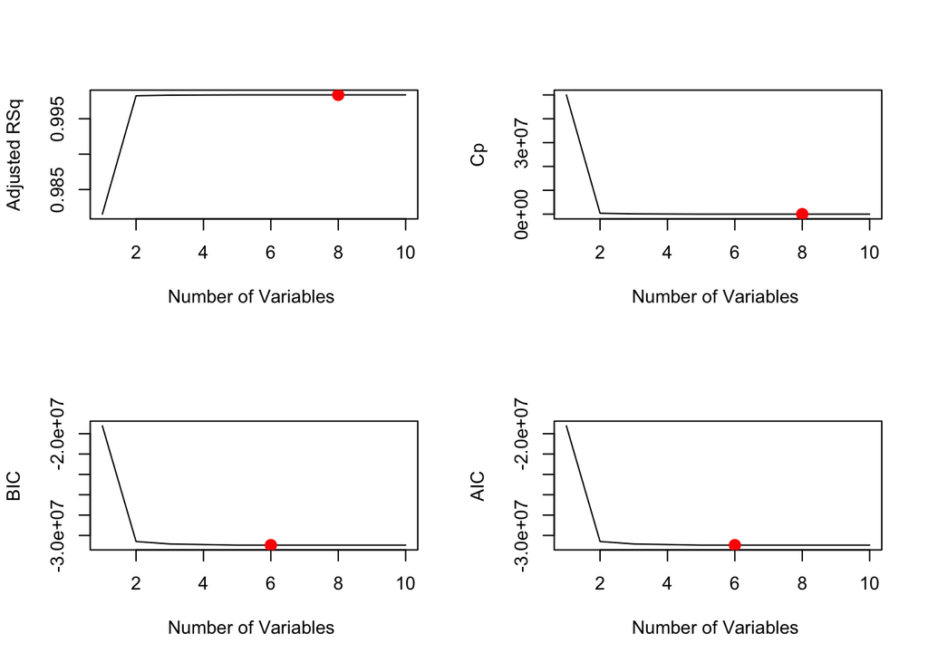

```r
n <- length(sst_insitu)
p <- 10
aic = regfit.summary$bic + (2-log(n))*(p+1)

par(mfrow=c(2,2))
plot(regfit.summary$adjr2 ,xlab="Number of Variables ", ylab="Adjusted RSq",type="l")
max_adjr2 = which.max(regfit.summary$adjr2)
points(max_adjr2,regfit.summary$adjr2[max_adjr2], col="red",cex=2,pch=20)
plot(regfit.summary$cp ,xlab="Number of Variables ",ylab="Cp", type='l')
min_cp = which.min(regfit.summary$cp )
points(min_cp,regfit.summary$cp[min_cp],col="red",cex=2,pch=20)
plot(regfit.summary$bic ,xlab="Number of Variables ",ylab="BIC",type='l')
min_bic = which.min(regfit.summary$bic )
points(min_bic,regfit.summary$bic[min_bic],col="red",cex=2,pch=20)
plot(x = seq(1,p),y = aic, xlab="Number of Variables ", ylab = "AIC",type="l")
min_aic = which.min(aic)
points(min_aic,aic[min_aic],col="red",cex=2,pch=20)
```

**Conclusion:** These plots tell us that best model obtained according Cp and adjusted R2 when there are eight variables in the model, while best model obtained according AIC, and BIC when there are six variables in the model.

Show some plots to provide evidence for your answer.

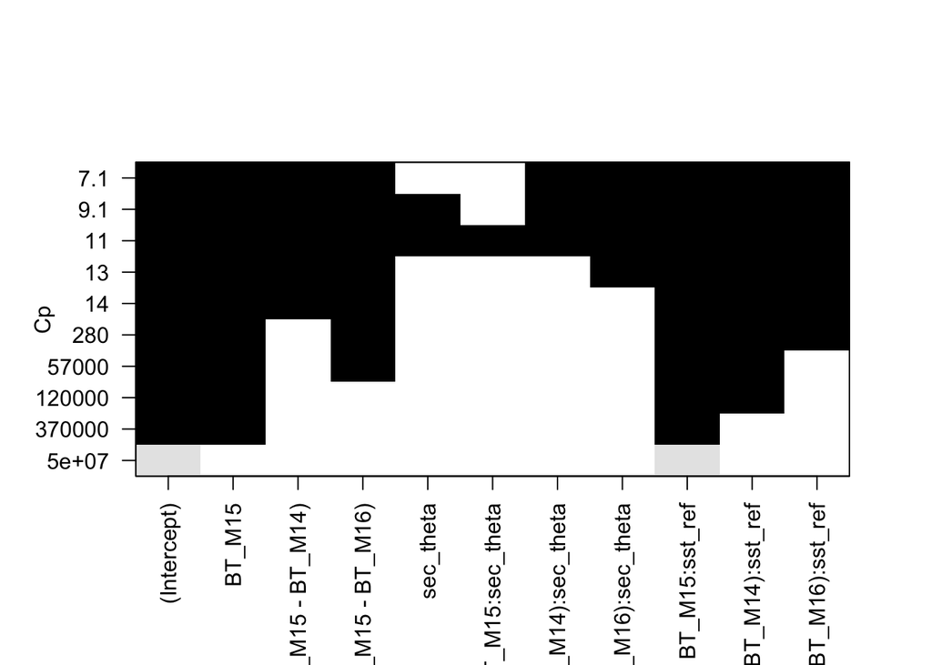

```r
plot(regfit.bwd, scale = "Cp")
```

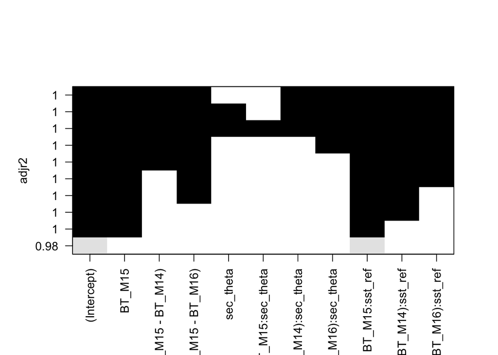

```r
plot(regfit.bwd, scale = "adjr2")
```

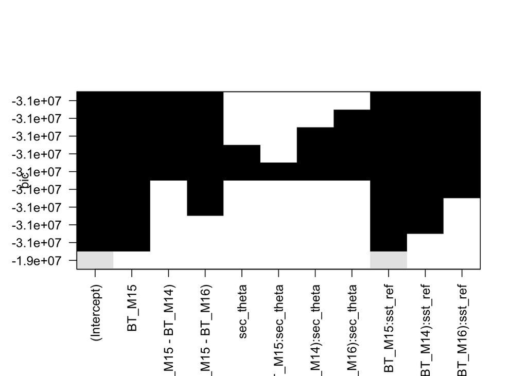

```r
plot(regfit.bwd, scale = "bic")
```

Report the coefficients of the best model obtained.

```r
coef(regfit.bwd, 8)
```

```
##                  (Intercept)                       BT_M15
##                 2.715284e+02                -9.073858e-01
##           I(BT_M15 - BT_M14)           I(BT_M15 - BT_M16)
##                -1.990981e-01                 3.609781e+00
## I(BT_M15 - BT_M14):sec_theta I(BT_M15 - BT_M16):sec_theta
##                 3.795537e-07                -9.394049e-07
##               BT_M15:sst_ref   I(BT_M15 - BT_M14):sst_ref
##                 3.345565e-03                 1.070138e-03
##   I(BT_M15 - BT_M16):sst_ref
##                -1.181171e-02
```

```r
coef(regfit.bwd, 6)
```

```
##                (Intercept)                     BT_M15
##              271.528486945               -0.907386554
##         I(BT_M15 - BT_M14)         I(BT_M15 - BT_M16)
##               -0.199052287                3.609753699
##             BT_M15:sst_ref I(BT_M15 - BT_M14):sst_ref
##                0.003345567                0.001069980
## I(BT_M15 - BT_M16):sst_ref
##               -0.011811616
```

## Question 6

Perform best subset selection on the training set (one of the matchup files), and plot the training set (using another matchup file) RMSE associated with the best model of each size.

```r
regfit.full = regsubsets(sst_insitu ~ ., data = dataframe2, nvmax=8)
reg.summary = summary(regfit.full)

reg.summary$rsq
```

```
## [1] 0.9989142 0.9990511 0.9990530 0.9990574 0.9990586 0.9990629 0.9990663
## [8] 0.9990663
```

```r
reg.summary$which
```

```
##   (Intercept)   sza sec_theta BT_M12 BT_M13 BT_M14 BT_M15 BT_M16 sst_ref
## 1        TRUE FALSE     FALSE  FALSE  FALSE  FALSE  FALSE  FALSE    TRUE
## 2        TRUE  TRUE     FALSE  FALSE  FALSE  FALSE  FALSE  FALSE    TRUE
## 3        TRUE  TRUE     FALSE  FALSE  FALSE  FALSE   TRUE  FALSE    TRUE
## 4        TRUE  TRUE     FALSE  FALSE  FALSE  FALSE   TRUE   TRUE    TRUE
## 5        TRUE  TRUE     FALSE  FALSE   TRUE  FALSE   TRUE   TRUE    TRUE
## 6        TRUE  TRUE     FALSE   TRUE   TRUE  FALSE   TRUE   TRUE    TRUE
## 7        TRUE  TRUE     FALSE   TRUE   TRUE   TRUE   TRUE   TRUE    TRUE
## 8        TRUE  TRUE      TRUE   TRUE   TRUE   TRUE   TRUE   TRUE    TRUE
```

```r
sqrt(mean(reg.summary$rss^2))
```

```
## [1] 508686.1
```

```r
sst_insitu_2 <- ncvar_get(In2, "sst_insitu")
sst_ref_2 <- ncvar_get(In2, "sst_ref")
sza_2 <- ncvar_get(In2, 'sza')
vza_2 <- ncvar_get(In2, 'vza')

BT_M12_2 <- ncvar_get(In2, "BT_M12")
BT_M13_2 <- ncvar_get(In2, "BT_M13")
BT_M14_2 <- ncvar_get(In2, "BT_M14")
BT_M15_2 <- ncvar_get(In2, "BT_M15")
BT_M16_2 <- ncvar_get(In2, "BT_M16")


dataframe3 = data.frame(sst_insitu_2, BT_M12_2, BT_M13_2, BT_M14_2, BT_M15_2, BT_M16_2, sst_ref_2, sza_2, vza_2)
head(dataframe3)
```

```
##   sst_insitu_2 BT_M12_2 BT_M13_2 BT_M14_2 BT_M15_2 BT_M16_2 sst_ref_2
## 1       302.95 301.8257 295.6567 290.1282 292.1880 289.0653  302.7027
## 2       302.95 301.6646 295.7045 290.2217 292.3900 289.2399  302.7043
## 3       302.95 301.6696 295.6878 290.2516 292.4353 289.3293  302.7060
## 4       302.95 301.9214 295.7280 290.1020 292.2581 289.1462  302.7036
## 5       302.95 301.7351 295.7818 290.2329 292.4271 289.2441  302.7052
## 6       302.95 301.5664 295.6924 290.2404 292.3982 289.2995  302.7068
##      sza_2     vza_2
## 1 13.76275 -44.02107
## 2 13.75438 -44.06536
## 3 13.74599 -44.10967
## 4 13.76458 -44.02121
## 5 13.75619 -44.06549
## 6 13.74780 -44.10979
```

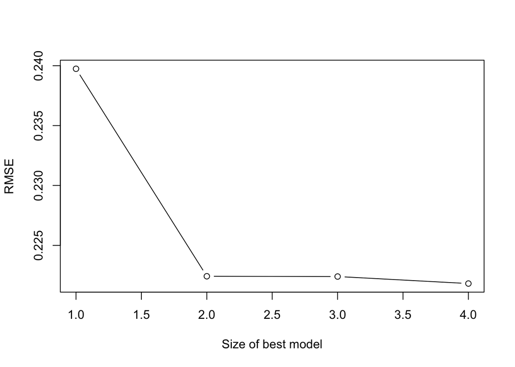

```r
model_varibale_1 = lm(sst_insitu_2~sst_ref_2, data=dataframe3)
rmse_varibale_1 = sqrt(mean(model_varibale_1$residuals^2))

model_varibale_2 = lm(sst_insitu_2~sst_ref_2 + sza_2, data=dataframe3)
rmse_varibale_2 = sqrt(mean(model_varibale_2$residuals^2))

model_varibale_3 = lm(sst_insitu_2~sst_ref_2 + sza_2 + BT_M15_2, data=dataframe3)
rmse_varibale_3 = sqrt(mean(model_varibale_3$residuals^2))

model_varibale_4 = lm(sst_insitu_2~sst_ref_2 + sza_2 + BT_M15_2 + BT_M16_2, data=dataframe3)
rmse_varibale_4 = sqrt(mean(model_varibale_4$residuals^2))

#model_varibale_5 = lm(sst_insitu_2~sst_ref_2 + sza_2 + BT_M15_2 + BT_M16_2 + BT_M13_2, data=dataframe3)
#rmse_varibale_5 = sqrt(mean(model_varibale_5$residuals^2))

#model_varibale_6 = lm(sst_insitu_2~sst_ref_2 + sza_2 + BT_M15_2 + BT_M16_2 + BT_M13_2 + BT_M12_2, data=dataframe3)
#rmse_varibale_6 = sqrt(mean(model_varibale_6$residuals^2))

#model_varibale_7 = lm(sst_insitu_2~sst_ref_2 + sza_2 + BT_M15_2 + BT_M16_2 + BT_M13_2 + BT_M12_2 + BT_M14_2, data=dataframe3)
#rmse_varibale_7 = sqrt(mean(model_varibale_7$residuals^2))

#model_varibale_8 = lm(sst_insitu_2~sst_ref_2 + sza_2 + BT_M15_2 + BT_M16_2 + BT_M13_2 + BT_M12_2 + BT_M14_2 + sec_theta, data=dataframe3)
#rmse_varibale_8 = sqrt(mean(model_varibale_8$residuals^2))


plot(c(1,2,3,4), c(rmse_varibale_1, rmse_varibale_2, rmse_varibale_3, rmse_varibale_4), type='b', xlab = 'Size of best model', ylab = 'RMSE')
```

For which model does the test set MSE take on its minimum value?

How does the model at which the test set MSE is minimized compare to the model used to generate the data?  
Does this agree with the coefficient values of the model?

## Question 7

Estimate the test error of your best model using the validation set approach (k- fold and/or bootstrap).  
Does it agree with your findings in part 6? Comment on the result.

## References

Anding, D. and R. Kauth. 1970. Estimation of sea surface temperature from space, Remote Sens. Environ., 1, 217-220.

Barton, I.J., 1995. Satellite-derived sea surface temperatures: Current status. Journal of Geophysical Research 100: 8777–8790.

Minnett, P.J. 1990. The regional optimization of infrared measurements of sea surface temperature from space. J. Geophys Res., 95

Petrenko, B.; Ignatov, A.; Kihai, Y.; Stroup, J.; Dash, P. 2014. Evaluation and selection of SST regression algorithms for JPSS VIIRS. J. Geophys. Res., 119, 4580–4599 https://agupubs.onlinelibrary.wiley.com/doi/epdf/10.1002/2013JD020637

Prabhakara, C., G. Dalau, and V.G. Kunde. 1974. Estimation of sea surface temperature from remote sensing in the 11 to 13mm window region, J. Geophys. Res., 79, 5039-5044.

Walton, C. C., W. G. Pichel, F. J. Sapper, and D. A. May, 1988. The development and operational application of nonlinear algorithms for the measurement of sea surface temperatures with NOAA polar-orbiting environmental satellites. Journal of Geophysical Research 103: 27999–28012.